# Random Forest Classifer: Classifying Autism Spectrum Disorder

Parabhjot Deol

25 April 2020

Included below is a code chunk used to read the data set.

```r
df <- read.csv("data/autism_data.csv")
```

# 1 Data Cleaning Steps

## 1.1 Look at the first few rows of data

```r
headTail(df) %>%
  datatable(rownames = TRUE, filter="top", options = list(pageLength = 10, scrollX=T)) %>%
  formatRound(columns=c(1:21), digits=0 )
```

|  | A1_Score | A2_Score | A3_Score | A4_Score | A5_Score | A6_Score | A7_Score | A8_Score | A9_Score | A10_Score | age | gender | ethnicity | jundice | austim | contry_of_res | used_app_before | result | age_desc | relation | Class.ASD |
| --- | --- | --- | --- | --- | --- | --- | --- | --- | --- | --- | --- | --- | --- | --- | --- | --- | --- | --- | --- | --- | --- |
| 1 | 1 | 1 | 1 | 1 | 0 | 0 | 1 | 1 | 0 | 0 | 26 | f | White-European | no | no | 'United States' | no | 6 | '18 and more' | Self | NO |
| 2 | 1 | 1 | 0 | 1 | 0 | 0 | 0 | 1 | 0 | 1 | 24 | m | Latino | no | yes | Brazil | no | 5 | '18 and more' | Self | NO |
| 3 | 1 | 1 | 0 | 1 | 1 | 0 | 1 | 1 | 1 | 1 | 27 | m | Latino | yes | yes | Spain | no | 8 | '18 and more' | Parent | YES |
| 4 | 1 | 1 | 0 | 1 | 0 | 0 | 1 | 1 | 0 | 1 | 35 | f | White-European | no | yes | 'United States' | no | 6 | '18 and more' | Self | NO |
| ... | ... | ... | ... | ... | ... | ... | ... | ... | ... | ... |  |  |  |  |  |  |  | ... |  |  |  |
| 701 | 1 | 0 | 0 | 0 | 0 | 0 | 0 | 1 | 0 | 1 | 34 | m | Hispanic | no | no | Mexico | no | 3 | '18 and more' | Parent | NO |
| 702 | 1 | 0 | 1 | 1 | 1 | 0 | 1 | 1 | 0 | 1 | 24 | f | ? | no | no | Russia | no | 7 | '18 and more' | ? | YES |
| 703 | 1 | 0 | 0 | 1 | 1 | 0 | 1 | 0 | 1 | 1 | 35 | m | 'South Asian' | no | no | Pakistan | no | 6 | '18 and more' | Self | NO |
| 704 | 1 | 0 | 1 | 1 | 1 | 0 | 1 | 1 | 1 | 1 | 26 | f | White-European | no | no | Cyprus | no | 8 | '18 and more' | Self | YES |

## 1.2 Look at structure of dataset

```r
str(df)
```

```
'data.frame':   704 obs. of  21 variables:
 $ A1_Score       : int  1 1 1 1 1 1 0 1 1 1 ...
 $ A2_Score       : int  1 1 1 1 0 1 1 1 1 1 ...
 $ A3_Score       : int  1 0 0 0 0 1 0 1 0 1 ...
 $ A4_Score       : int  1 1 1 1 0 1 0 1 0 1 ...
 $ A5_Score       : int  0 0 1 0 0 1 0 0 1 0 ...
 $ A6_Score       : int  0 0 0 0 0 0 0 0 0 1 ...
 $ A7_Score       : int  1 0 1 1 0 1 0 0 0 1 ...
 $ A8_Score       : int  1 1 1 1 1 1 1 0 1 1 ...
 $ A9_Score       : int  0 0 1 0 0 1 0 1 1 1 ...
 $ A10_Score      : int  0 1 1 1 0 1 0 0 1 0 ...
 $ age            : Factor w/ 47 levels "?","17","18",..: 11 9 12 20 26 21 2 47 14 2 ...
 $ gender         : Factor w/ 2 levels "f","m": 1 2 2 1 1 2 1 2 2 2 ...
 $ ethnicity      : Factor w/ 12 levels "'Middle Eastern '",..: 12 7 7 12 3 9 5 12 12 4 ...
 $ jundice        : Factor w/ 2 levels "no","yes": 1 1 2 1 1 2 1 1 1 2 ...
 $ austim         : Factor w/ 2 levels "no","yes": 1 2 2 2 1 1 1 1 1 2 ...
 $ contry_of_res  : Factor w/ 67 levels "'Costa Rica'",..: 11 26 62 11 33 11 11 4 11 22 ...
 $ used_app_before: Factor w/ 2 levels "no","yes": 1 1 1 1 1 1 1 1 1 1 ...
 $ result         : int  6 5 8 6 2 9 2 5 6 8 ...
 $ age_desc       : Factor w/ 1 level "'18 and more'": 1 1 1 1 1 1 1 1 1 1 ...
 $ relation       : Factor w/ 6 levels "'Health care professional'",..: 6 6 4 6 2 6 6 4 6 1 ...
 $ Class.ASD      : Factor w/ 2 levels "NO","YES": 1 1 2 1 1 2 1 1 1 2 ...
```

## 1.3 Find all variables with NAs

```r
na_count <-sapply(df, function(y) sum(length(which(is.na(y)))))
na_count <- data.frame(na_count)
na_count
```

```
                na_count
A1_Score               0
A2_Score               0
A3_Score               0
A4_Score               0
A5_Score               0
A6_Score               0
A7_Score               0
A8_Score               0
A9_Score               0
A10_Score              0
age                    0
gender                 0
ethnicity              0
jundice                0
austim                 0
contry_of_res          0
used_app_before        0
result                 0
age_desc               0
relation               0
Class.ASD              0
```

## 1.4 Look at all the unique values that each variable takes on.

```r
for (i in c(1:ncol(df))) {
  print(colnames(df)[i])
  print(table(df[,i], useNA="always"))
}
```

```
[1] "A1_Score"

   0    1 <NA>
 196  508    0
[1] "A2_Score"

   0    1 <NA>
 385  319    0
[1] "A3_Score"

   0    1 <NA>
 382  322    0
[1] "A4_Score"

   0    1 <NA>
 355  349    0
[1] "A5_Score"

   0    1 <NA>
 353  351    0
[1] "A6_Score"

   0    1 <NA>
 504  200    0
[1] "A7_Score"

   0    1 <NA>
 410  294    0
[1] "A8_Score"

   0    1 <NA>
 247  457    0
[1] "A9_Score"

   0    1 <NA>
 476  228    0
[1] "A10_Score"

   0    1 <NA>
 300  404    0
```

[output cut: 89 more lines]

```
          704             0
[1] "relation"

'Health care professional'                          ?
                         4                         95
                    Others                     Parent
                         5                         50
                  Relative                       Self
                        28                        522
                      <NA>
                         0
[1] "Class.ASD"

  NO  YES <NA>
 515  189    0
```

## 1.5 Convert variables to numeric

Age was interpretted as a factor when loading the dataset, convert this to numeric.

```r
df$age <- as.numeric(as.character(df$age))
```

## 1.6 Convert to factors

We see most of the score variables are numeric and should be converted to factor.

```r
df <- within(df, {
  A1_Score <- factor(A1_Score)
  A2_Score <- factor(A2_Score)
  A3_Score <- factor(A3_Score)
  A4_Score <- factor(A4_Score)
  A5_Score <- factor(A5_Score)
  A6_Score <- factor(A6_Score)
  A7_Score <- factor(A7_Score)
  A8_Score <- factor(A8_Score)
  A9_Score <- factor(A9_Score)
  A10_Score <- factor(A10_Score)
})
```

## 1.7 Use the x-ray package to create plots to visualize the data

Now that the data is in the correct format, we can visualize it using the x-ray package.

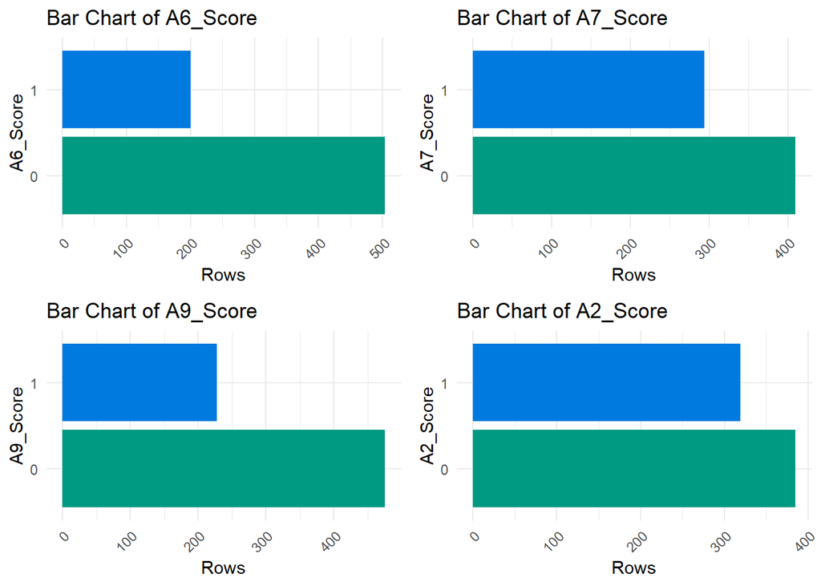

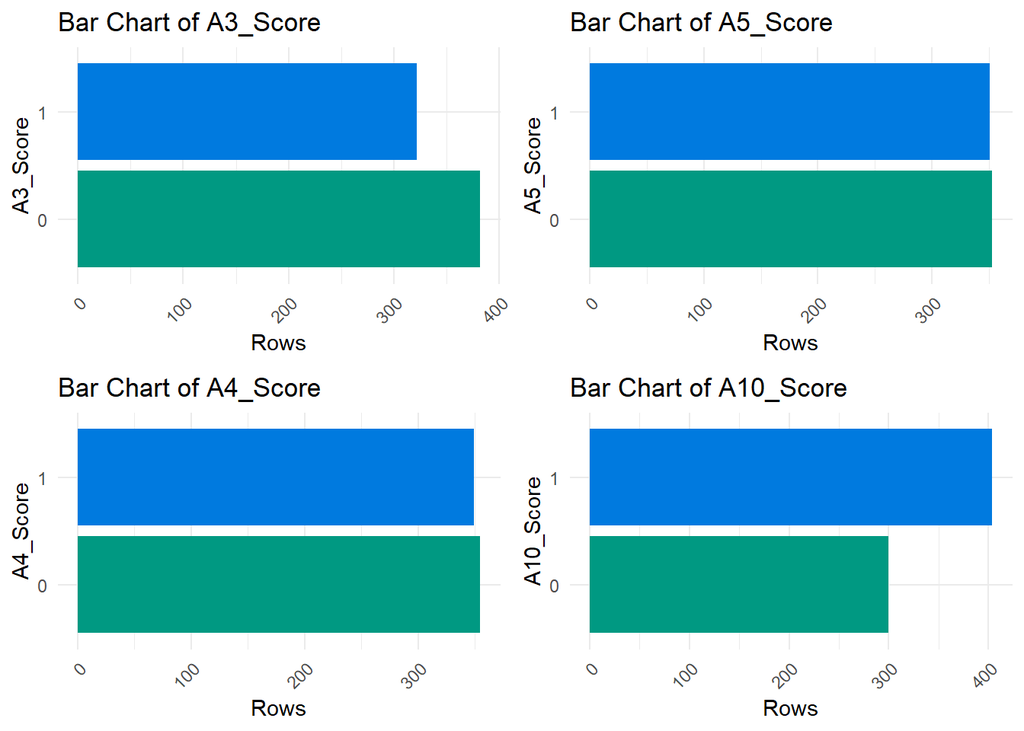

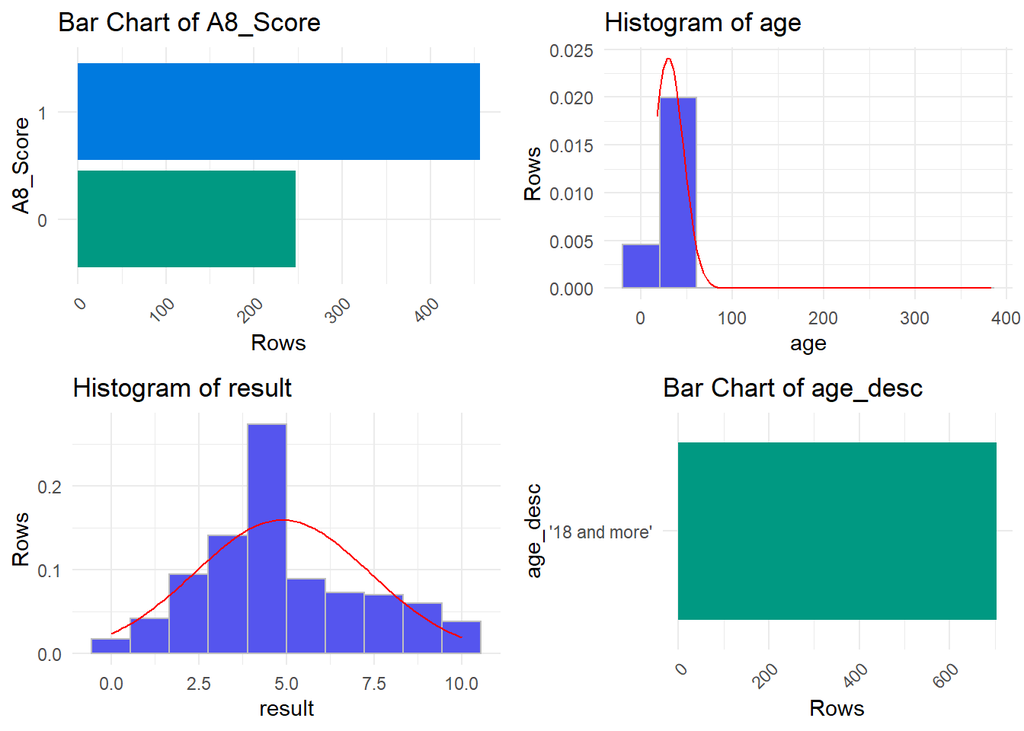

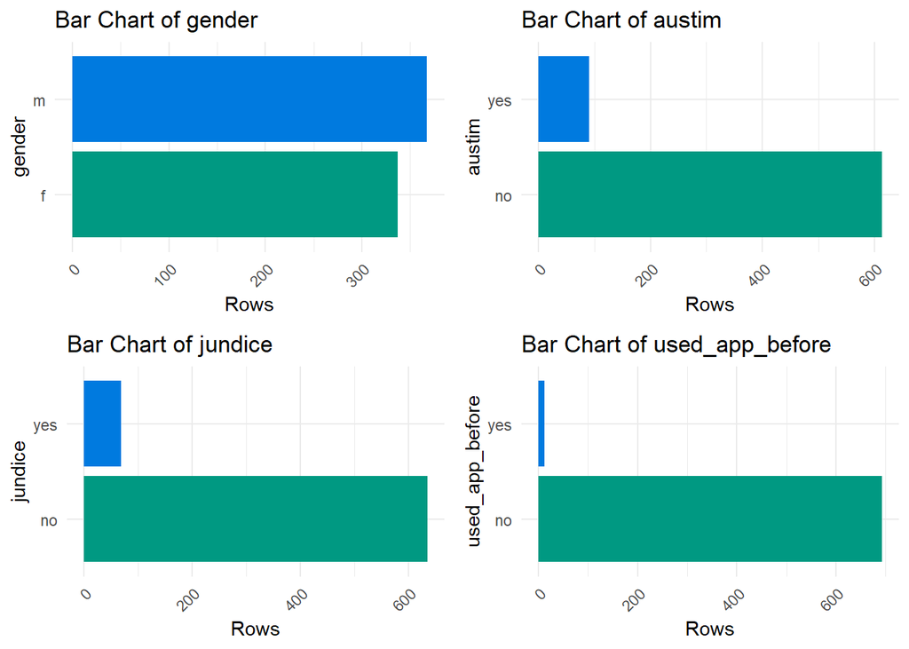

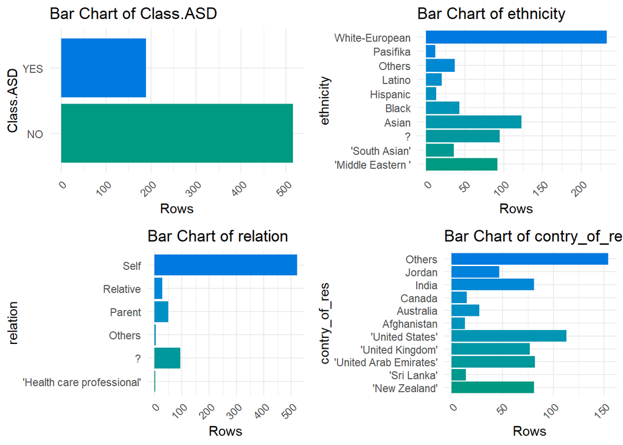

```
  Variable p_1 p_10 p_25 p_50 p_75 p_90  p_99
1   result   0    2    3    4    7    9    10
2      age  17   19   21   27   35   43 57.98
```

```r
distributions( df[ , -c(1) ] )
```

## 1.8 Updates to make

After all exploratory data analysis, we notice the following updates to make:  
- Age has an outlier point and some observations have age = “?”  
- 95 observations have ethnicity = “?”  
- Country of res has too many low count groups  
- The variable age_desc has no value since all observations fall into a single category  
- Relation has 95 observations = “?”  
- Take out variables that are not logical such as “used_app_before” and “relation” of the person who filled out the form

We update the df below:

```r
df_reduced <- df[ , !(names(df) %in% "contry_of_res")]
df_reduced <- df_reduced[ , !(names(df_reduced) %in% "used_app_before")]
df_reduced <- df_reduced[ , !(names(df_reduced) %in% "relation")]
df_reduced <- df_reduced[ , !(names(df_reduced) %in% "age_desc")]
df_reduced<- df_reduced[ , !(names(df_reduced) %in% "result")]
df_reduced <- df_reduced[ , !(names(df_reduced) %in% "ethnicity")]
df_reduced <- df_reduced[!(df_reduced$age>150),]
df_reduced <- na.omit(df_reduced)
```

# 2 Random Forest Classifier

Used this guide: https://www.r-bloggers.com/how-to-implement-random-forests-in-r/

## 2.1 Split the data into training and testing sets

```r
set.seed(123)
training.samples <- df_reduced$Class.ASD %>% createDataPartition(p = 0.7, list = FALSE)
df_train <- df_reduced[training.samples, ]
df_test <- df_reduced[-training.samples, ]
```

## 2.2 Load required Libraries

```r
pacman::p_load(randomForest, caret, e1071)
```

## 2.3 Create a Random Forest model with default parameters

```r
model1 <- randomForest(Class.ASD ~ ., data = df_train, importance = TRUE)
model1
```

```
Call:
 randomForest(formula = Class.ASD ~ ., data = df_train, importance = TRUE)
               Type of random forest: classification
                     Number of trees: 500
No. of variables tried at each split: 3

        OOB estimate of  error rate: 3.25%
Confusion matrix:
     NO YES class.error
NO  352   7  0.01949861
YES   9 124  0.06766917
```

We can fine tune parameters of Random Forest model by:  
1. Changing the number of trees (ntree)  
2. Changing the number of variables randomly sampled at each stage (mtry)

Ntree: Number of trees to grow. This should not be set to too small a number, to ensure that every input row gets predicted at least a few times.

Mtry: Number of variables randomly sampled as candidates at each split. The default values are different for classification (sqrt(p) where p is number of variables in x) and regression (p/3)

## 2.4 Change model parameters

The model below was run a few times with different parameters and updated using the results from further analyses below.

```r
model2 <- randomForest(Class.ASD ~ ., data = df_train,
                       ntree = 1500, mtry = 3, importance = TRUE)
model2
```

```
Call:
 randomForest(formula = Class.ASD ~ ., data = df_train, ntree = 1500,      mtry = 3, importance = TRUE)
               Type of random forest: classification
                     Number of trees: 1500
No. of variables tried at each split: 3

        OOB estimate of  error rate: 3.86%
Confusion matrix:
     NO YES class.error
NO  353   6  0.01671309
YES  13 120  0.09774436
```

## 2.5 Test on the the train set

```r
predTrain <- predict(model2, df_train, type = "class")
# Checking classification accuracy
mean(predTrain == df_train$Class.ASD)
```

```
[1] 1
```

```r
table(predTrain, df_train$Class.ASD)
```

```
predTrain  NO YES
      NO  359   0
      YES   0 133
```

## 2.6 See what variables are the most important

```r
importance(model2)
```

```
                  NO       YES MeanDecreaseAccuracy MeanDecreaseGini
A1_Score  22.4002772 38.830944           39.9857989        10.350257
A2_Score  23.2141176 30.929235           35.3135713         9.466557
A3_Score  13.3293077 37.296153           35.9149207        16.341721
A4_Score  22.3773242 43.654743           45.9012581        19.406069
A5_Score  21.3655087 52.381636           52.0572461        22.498688
A6_Score  28.1781148 30.566406           38.4925863        22.950728
A7_Score  19.8119550 31.501324           34.9262334         9.821174
A8_Score  16.0468334 28.658829           30.0807000         7.698098
A9_Score  29.9265261 46.457001           51.5060456        34.326673
A10_Score 11.7449952 31.144477           30.5074269         9.408807
age        6.7133053  3.422985            7.2973030        12.236581
gender     1.7577398  2.511231            3.0990986         2.971339
jundice    6.9826765 -3.186574            3.9184420         1.665364
austim    -0.8190871  1.213259            0.3066293         1.953964
```

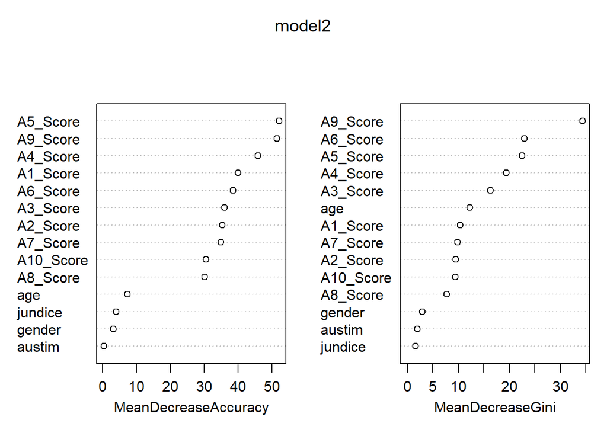

```r
varImpPlot(model2)
```

## 2.7 Test on the testing set

```r
predValid <- predict(model2, df_test, type = "class")
# Checking classification accuracy
mean(predValid == df_test$Class.ASD)
```

```
[1] 1
```

```r
table(predValid,df_test$Class.ASD)
```

```
predValid  NO YES
      NO  153   0
      YES   0  56
```

Model 2 performed well on the training set with 100% accuracy, and also achieved 100% accuracy on the testing set.

## 2.8 Using a loop to identify the right mtry for model and input into the model above.

```r
a=c()
for (i in 1:20) {
  model3 <- randomForest(Class.ASD ~ .,
                         data = df_train, ntree = 1500,
                         mtry = i, importance = TRUE)
  predValid <- predict(model3, df_test, type = "class")
  a[i] = mean(predValid == df_test$Class.ASD)
}

a
```

```
 [1] 0.9473684 0.9856459 1.0000000 1.0000000 0.9904306 0.9904306 0.9856459
 [8] 0.9760766 0.9808612 0.9665072 0.9617225 0.9521531 0.9425837 0.9473684
[15] 0.9473684 0.9473684 0.9521531 0.9473684 0.9521531 0.9473684
```

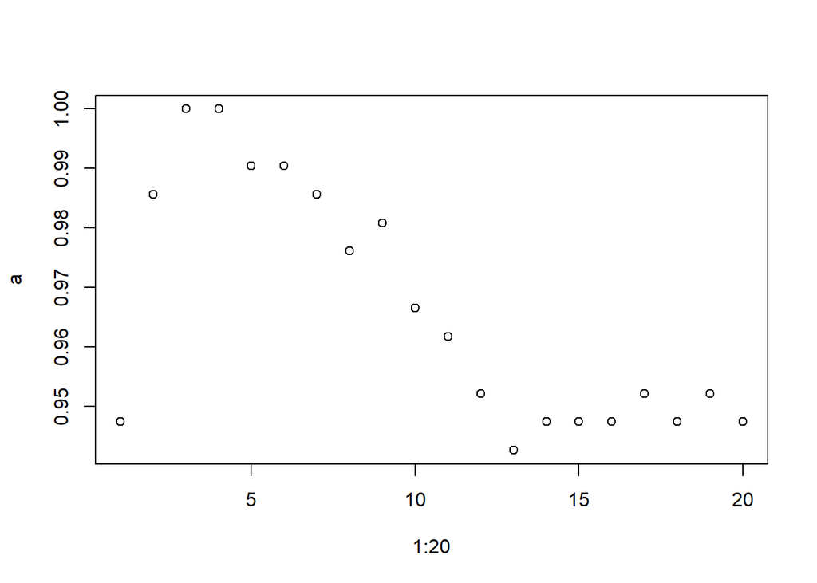

```r
plot(1:20,a)
```

The graph shows us what the accuracy of the model is at each mtry simulation. We see that mtry of 3 is the one used in model 2 above and it produces the best model.

## 2.9 Conclusions

That is all in my attempt to use a random forest classifier. The model created appears to have good accuracy, but I am uncertain of the results because I do not have a good understanding of the data set variables. I might be including variables that will not be available until after the diagnosis.